# STOR 320 Final Paper

STOR 320.01 Group 8

May 01, 2024

# INTRODUCTION

Despite being well prepared for a disaster, many incidents, such as hurricanes or fires, can still greatly impact communities due to the significant damage they cause. These disasters test communities’ resilience and aid programs’ responsiveness. This paper explores how models can predict and optimize the effectiveness of disaster response and aid distribution.

We first investigated factors influencing the amount of aid allocated to disaster claims, focusing on inflation-adjusted figures. This question can provide insights into the effectiveness and equity of aid distribution. By understanding which factors influence the aid received, stakeholders can identify potential biases or inefficiencies in the distribution process. This has worldwide implications as equitable aid distribution is imperative for recovery. It can impact how quickly and effectively communities can rebound from disasters.

Our second question examined how the COVID-19 pandemic impacts the frequency and nature of FEMA biological disaster claims across different cities, and the relationship between aid received for these events and the presence of elderly occupants in affected households. After filtering the data based on COVID-19 dates, we delved into how well the attributes of disaster claims, the type of aid received, household composition, and additional factors such as insurance coverage can predict the presence of occupants over 65 years old. This is particularly interesting as it explores whether a global health crisis affects disaster response’s financial and logistical aspects, which could reveal vulnerabilities or strengths in current emergency management strategies. Understanding this is important as it can help tailor disaster response efforts to be more effective and sensitive to the community’s needs.

These questions could impact many disaster response policies. For data owners, such as FEMA or other disaster response organizations, the answers to these questions can drive more informed policy-making, improve operational efficiencies, and enhance the targeting of resources. For the global community, especially those in disaster-prone areas, these insights promise more timely and appropriate disaster response, which can ultimately save lives and reduce the long-term socio-economic impacts of disasters.

# DATA

We chose to analyze a comprehensive collection of applicant-level data for the Individuals and Households Program (IHP), managed by the Federal Emergency Management Agency (FEMA). This [data](https://www.fema.gov/openfema-data-page/individuals-and-households-program-valid-registrations-v1) originates from FEMA’s National Emergency Management Information System (NEMIS), which has collected self-reported details from applicants affected by various disasters across the United States since 2002 (https://www.fema.gov/openfema-data-page/individuals-and-households-program-valid-registrations-v1). Each entry in the dataset represents an application for aid following a disaster, capturing a range of information from basic demographics to detailed descriptions of the damage and aid requested. This system manages and records the assistance provided to individuals and households in the aftermath of disasters. The data is collected directly from aid applicants, making it a primary source of information for understanding FEMA’s operations and the impact of its assistance programs.

This dataset is a sample of all applications for disaster-related assistance filed with FEMA under the IHP from 2002 until April 27th, 2024. It encompasses various disaster types and geographies, reflecting how the American population is affected by disasters. Each observation in the dataset represents an individual application for disaster assistance under FEMA’s IHP. This includes all valid registrants who have applied within a declared county and the registration period for each disaster event. A table with a sample of the dataset is shown below:

| incidentType | declarationDate | damagedCity | occupants65andOver | IAppfvl | personalPropertyEligible | disasterNumber | ihpMax | haStatus | rentalAssistanceEligible | autoDamage | tsaEligible | residenceType | sbaApproved | grossIncome | homeOwnersInsurance | IAfloodDamageAmount | applicantAge |
| --- | --- | --- | --- | --- | --- | --- | --- | --- | --- | --- | --- | --- | --- | --- | --- | --- | --- |
| Severe Storm | 2002-11-05 | PORTLAND | 0 | 0.00 | 0 | 1439 | 0 | NA | 0 | 1 | 0 | House/Duplex | 0 | $15,000-$30,000 | 0 | 0.0000 | 35-49 |
| Typhoon | 2002-12-08 | YIGO | 0 | 12203.33 | 1 | 1446 | 0 | ER - Eligible - Rental Assistance | 1 | 0 | 0 | House/Duplex | 0 | <$15,000 | 0 | 0.0000 | 35-49 |
| Severe Storm | 2002-11-05 | CORPUS CHRISTI | 0 | 0.00 | 0 | 1439 | 0 | IID- Ineligible - Insufficient Damage | 0 | 1 | 0 | House/Duplex | 0 | $15,000-$30,000 | 1 | 539.3647 | 50-64 |
| Severe Storm | 2002-11-05 | EDINBURG | 0 | 0.00 | 0 | 1439 | 0 | EHR - Eligible - Home Repairs | 0 | 0 | 0 | Mobile Home | 0 | $15,000-$30,000 | 1 | 110.1425 | 50-64 |
| Severe Storm | 2002-11-05 | EDINBURG | 0 | 0.00 | 0 | 1439 | 0 | ER - Eligible - Rental Assistance | 1 | 0 | 0 | House/Duplex | 0 | $15,000-$30,000 | 0 | 0.0000 | 35-49 |
| Typhoon | 2002-12-08 | MONG MONG | 0 | 0.00 | 0 | 1446 | 0 | INP - Ineligible - Not Primary Residence | 0 | 0 | 0 | House/Duplex | 0 | $30,001-$60,000 | 0 | 0.0000 | 19-34 |

Several specific variables within the dataset are of particular interest:

1. **`ihpAmount`**: The total financial IHP award for Housing Assistance and Other Needs Assistance. This variable is crucial for modeling the aid received and understanding the distribution of funds.  
2. **`fipAmount`**: The applicant’s Flood Insurance Premium amount. This variable was important to calculate overall aid received and understand the distribution of funds.  
3. **`declarationDate`**: The date on which the disaster was officially declared. This helps in segmenting the data into pre-and post-COVID periods.  
4. **`incidentType`**: Describes the type of disaster, such as fire or flood, which could influence the amount and type of aid disbursed.  
5. **`damagedStateAbbreviation`** and **`county`**: These geographical identifiers are essential for analyzing regional patterns in aid distribution.  
6. **`householdComposition`**: Reflects the number of individuals affected in each household, potentially impacting the urgency and amount of aid.  
7. **`grossIncome`**: Provides context on the economic status of the applicants, which may correlate with the amount of aid received.

The figure below shows the frequency of the type of disasters in the dataset that could influence the amount and type of aid distributed.

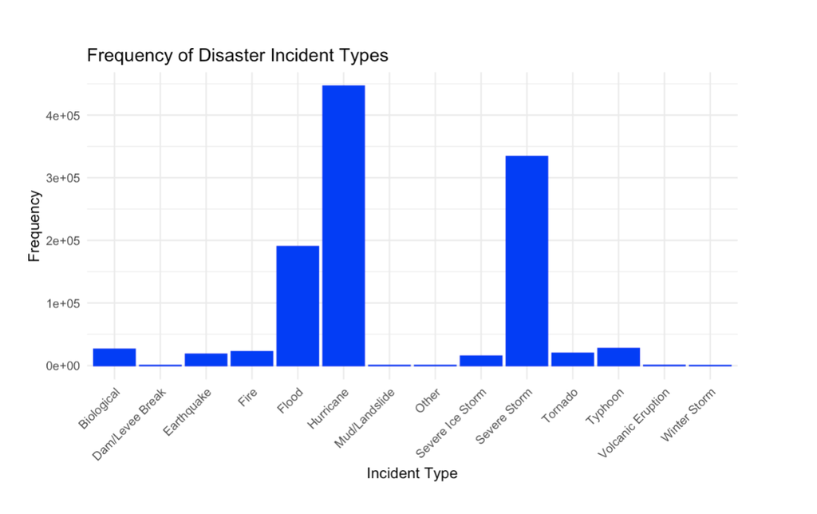

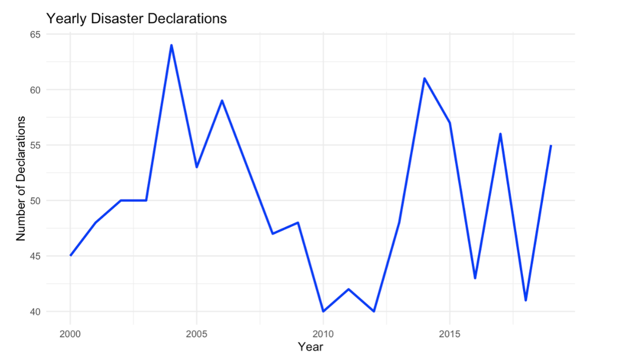

# RESULTS

## Q1: What is an appropriate model to predict a claim’s aid received, after adjusting for inflation?

The full method of selecting a model to predict inflation-adjusted aid received is outlined [here](https://isabelle-raad.github.io/Stor320-Final-Project/ModelSelection.html). The process of model refining began with a dataset of 50,000 selected claims per year and 63 total variables. This was eventually narrowed down to 19 through stepwise selection based on the variable’s significance and relevance. Variables such as **haStatus**, which showed a high F-value indicating a significant impact on aid received, were critically evaluated for their influence on the model’s accuracy.

Adjustments were made to address multicollinearity and to simplify the model. For instance, **onaEligible** was removed due to its strong correlation with **personalPropertyEligible**, and variables with the lowest F-values like **homeDamage**, **ihpEligible**, and **householdComposition** were also eliminated. Variables with the lowest F-values, such as **homeDamage**, **ihpEligible**, and **householdComposition** were also eliminated. Interaction terms and polynomial transformations were explored to capture nuanced relationships between variables, the interaction between disaster type and maximum allowable **IHP aid**, **disasterNumber** and **ihpMax**, and polynomial terms for property and flood damage amounts. This led to an increase in the model’s R-squared, showing a more accurate overall model. After checking residuals and fitted values, we decided to take the natural log of the aid-received response variable and raise it to the power of 2.5. This yielded the highest R-squared of values used and the most normal residuals. Claims with a Cook’s distance of over 0.05 and highly unusual residuals were removed from the training of our final model. After adjusting for inflation, our final model accounts for 78.77% of aid received. A table of coefficients of predictors is given at the end of the previously linked html file discribing the model creation process.

The subsequent 30-fold cross-validation revealed a mean absolute error (MAE) of 6.07e+18, which was attributable to one-fold with high outliers. All other data folds had MAEs of under 2,000. This lower MAE of $2,000 suggests that our model is making more accurate predictions and that the difference between observed and predicted inflation-adjusted aid awards is relatively small. By comparison, a 30-fold cross-validation of the empty model resulted in a mean MAE of 27,665,346,995. A mean absolute error estimation of a model with all variables included was beyond the computation capabilities of this team, but a model without interaction effects has a mean MAE of 2.633175e+15 under 10-fold cross-validation. Despite the unusually high mean MAE for our model, an individual analysis of MAE for folds of data suggests that the model is better at predicting FEMA Aid Received for most zip codes than an empty model or one without interaction effects.

Using the cross-validated model, we want to understand the relationship between the disaster number and predicted aid. We must make helper functions to allow for a single disaster input into the model. Then it filters out the data for that specific disaster number and inputs the data into mod14 to predict, and then the predictions are transformed back into aid received values using another helper function. We can then call this helper function for a vector of disaster numbers to have it apply to all of them. Figure 1.A below summarizes the mean aid received for each disaster number. We see one data point that is extreme, due to model imperfections.

### Figure 1A

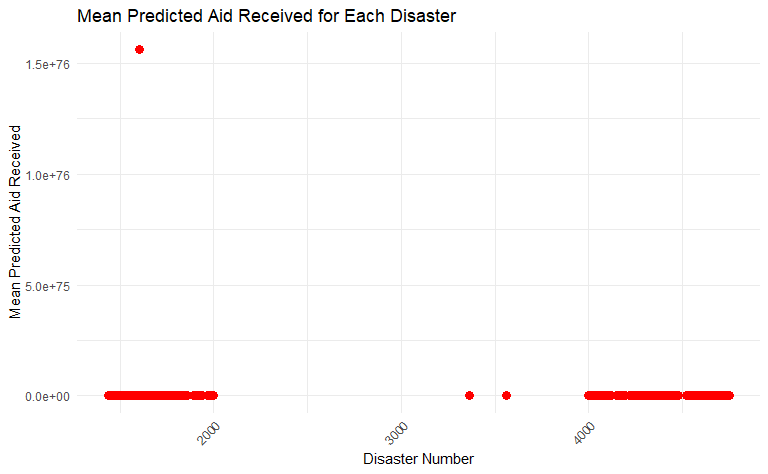

### Figure 1B

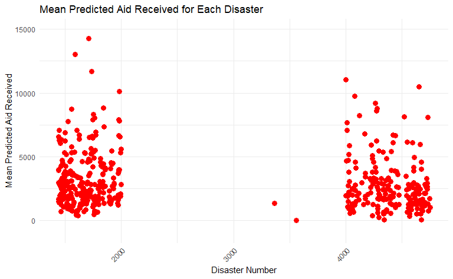